# Analysis by funtional group per depth within site

# 4 MANTEL TEST

```r
library(fields)
library(reshape2)
library(ade4)
library(adespatial)
library(spdep)
```

```r
library(ggplot2)
```

Load distance file and create distance matrix

```r
Ok_dist_69 <- read.csv(file=here("Multi-taxa_data","Ok_dist_69.csv"), row.names=1 )
head(Ok_dist_69)
```

```
##                  Long      Lat
## AW_deep_1    127.9136 26.60075
## AW_deep_2    127.9136 26.60075
## AW_deep_3    127.9136 26.60075
## AW_shallow_1 127.9136 26.60075
## AW_shallow_2 127.9136 26.60075
## AW_shallow_3 127.9136 26.60075
```

```r
Dist_km <- as.dist(rdist.earth(Ok_dist_69, miles=F))

func_bray <- vegdist(func_mat, method = "bray")
```

Correlation between straight-line geographic distance and dissimilarity in species composition

```r
set.seed(69)
mantel(Dist_km, func_bray)
```

```
##
## Mantel statistic based on Pearson's product-moment correlation
##
## Call:
## mantel(xdis = Dist_km, ydis = func_bray)
##
## Mantel statistic r: 0.03506
##       Significance: 0.247
##
## Upper quantiles of permutations (null model):
##    90%    95%  97.5%    99%
## 0.0674 0.0826 0.0975 0.1196
## Permutation: free
## Number of permutations: 999
```

Plot

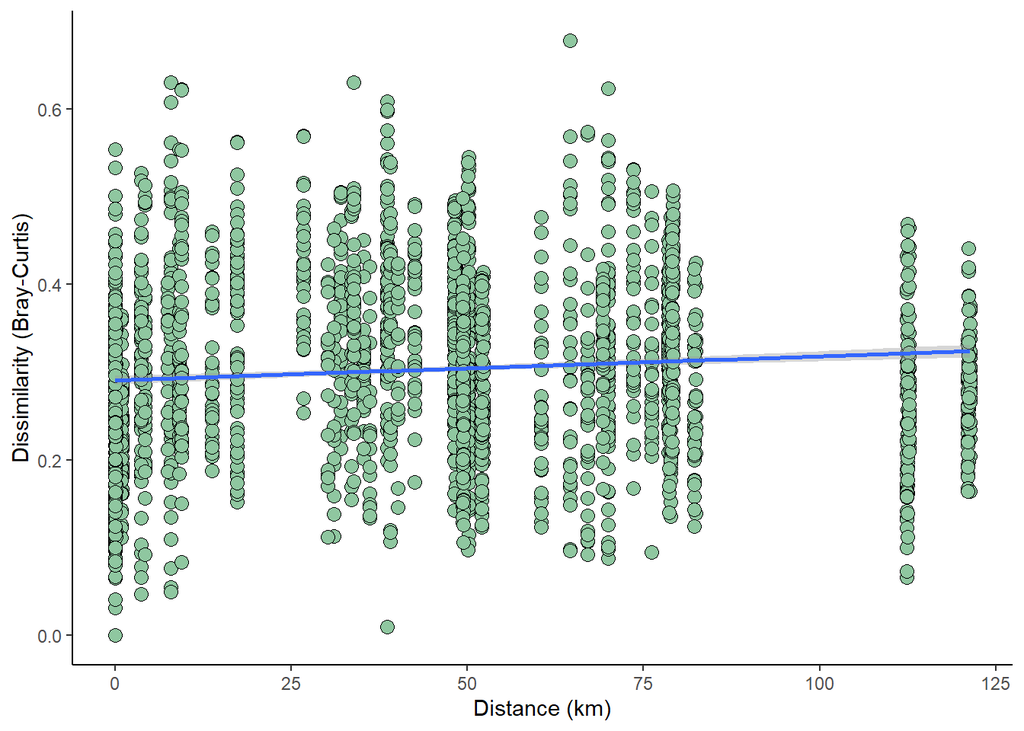

```r
func_matrix_dist <- data.frame(x = melt(as.matrix(Dist_km))$value,
                          y = melt(as.matrix(func_bray))$value) ## Prepare data for graphic

ggplot(func_matrix_dist) +
  geom_jitter( aes(x,y), shape = 21, size = 3, fill = "#8fc7a0") +
  labs(x = "Distance (km)",
       y = "Dissimilarity (Bray-Curtis)") +
  geom_smooth( aes(x,y), method = "glm") +
  theme_classic()
```

```r
ggsave("func_dissimil_distance.tiff",
       units="in", width=6, height=4, dpi=300, compression = 'lzw',
       path = here ("Multi-taxa_data","PLITs","4-Visualization_outputs"))

ggsave("func_dissimil_distance.png",
       units="in", width=6, height=4, dpi=300,
       path = here ("Multi-taxa_data","PLITs","4-Visualization_outputs"))
```

Mantel

```r
set.seed(69)
mantel_func <- mantel.randtest(func_bray, Dist_km)
mantel_func
```

```
## Monte-Carlo test
## Call: mantel.randtest(m1 = func_bray, m2 = Dist_km)
##
## Observation: 0.03506151
##
## Based on 999 replicates
## Simulated p-value: 0.221
## Alternative hypothesis: greater
##
##       Std.Obs   Expectation      Variance
##  0.7415034960 -0.0008536382  0.0023460046
```

# 5 Boxplot with within-site distance from centroids made with `ggplot()`

Load packages

```r
library(here)
library(vegan)#load package
library(MASS)
library(dplyr)
library(readxl)   # to import excel datasets
```

Load input dataframe

```r
func_input<- read_excel(here("Multi-taxa_data","PLITs","3-Clean_data","func_clean.xlsx"), sheet = "func_input")

func_input <- func_input %>%
  mutate(Pressure = case_when(Site == 'HI' |
                              Site == "S1" |
                              Site == "S2" ~ "Low",
                              Site == "ZP" |
                              Site == 'ZA' |
                              Site == "YO" |
                              Site == "MI" ~ "Medium",
                              Site == 'SK' |
                              Site == 'SN' |
                              Site == "AW" |
                              Site == "G1" |
                              Site == "G2"~ "High"))

func_input <- func_input[ ,c(1:5, 20, 6:19)]

func_input[,c(1:6)] <- lapply(func_input[,c(1:6)], as.factor)

func_input$Pressure<-ordered(func_input$Pressure,levels=c("Low", "Medium", "High"))

func_input$Site <- ordered(func_input$Site, levels= c("HI", "S1", "S2", "ZP", "ZA", "YO", "MI","SK", "SN", "AW", "G1", "G2"))

str(func_input)
```

```
## tibble [69 × 20] (S3: tbl_df/tbl/data.frame)
##  $ Trans     : Factor w/ 69 levels "AW_D1","AW_D2",..: 1 2 3 4 5 6 7 8 9 10 ...
##  $ Site      : Ord.factor w/ 12 levels "HI"<"S1"<"S2"<..: 10 10 10 10 10 10 11 11 11 11 ...
##  $ Depth     : Factor w/ 2 levels "Deep","Shallow": 1 1 1 2 2 2 1 1 1 2 ...
##  $ Rep       : Factor w/ 3 levels "1","2","3": 1 2 3 1 2 3 1 2 3 1 ...
##  $ Site_depth: Factor w/ 23 levels "AW_Deep","AW_Shallow",..: 1 1 1 2 2 2 3 3 3 4 ...
##  $ Pressure  : Ord.factor w/ 3 levels "Low"<"Medium"<..: 3 3 3 3 3 3 3 3 3 3 ...
##  $ submassive: num [1:69] 0 14.6 52.9 41.2 27.3 40.2 4.9 0 0 1.3 ...
##  $ encrusting: num [1:69] 0 52.1 42.6 25.5 7 8.4 79.5 88.4 93.2 62.2 ...
##  $ hispidose : num [1:69] 0 22.9 0 0 0 2.2 0 0 0 0 ...
##  $ plate     : num [1:69] 0 10.4 4.4 9.8 0 0 3.4 9 6.6 0 ...
##  $ corymbose : num [1:69] 0 0 0 5.9 0 5.6 0 0 0 0 ...
##  $ massive   : num [1:69] 0 0 0 17.6 3.5 29.6 0 2.6 0.3 4.8 ...
##  $ table     : num [1:69] 0 0 0 0 34.9 14 0 0 0 0 ...
##  $ laminar   : num [1:69] 0 0 0 0 27.3 0 0 0 0 0 ...
##  $ foliose   : num [1:69] 0 0 0 0 0 0 12.1 0 0 31.7 ...
##  $ branching : num [1:69] 0 0 0 0 0 0 0 0 0 0 ...
##  $ digitate  : num [1:69] 0 0 0 0 0 0 0 0 0 0 ...
##  $ turf      : num [1:69] 100 97.9 99.3 99.9 99.4 99.8 98.2 94.1 92.5 65.9 ...
##  $ CCA       : num [1:69] 0 2.1 0.7 0.1 0.6 0.2 1.8 5.9 6.2 34.1 ...
##  $ macroalgae: num [1:69] 0 0 0 0 0 0 0 0 1.3 0 ...
```

```r
#create a df with the independent variables
ind_df <- as.data.frame(func_input[,c(1:6)])
str(ind_df)
```

```
## 'data.frame':    69 obs. of  6 variables:
##  $ Trans     : Factor w/ 69 levels "AW_D1","AW_D2",..: 1 2 3 4 5 6 7 8 9 10 ...
##  $ Site      : Ord.factor w/ 12 levels "HI"<"S1"<"S2"<..: 10 10 10 10 10 10 11 11 11 11 ...
##  $ Depth     : Factor w/ 2 levels "Deep","Shallow": 1 1 1 2 2 2 1 1 1 2 ...
##  $ Rep       : Factor w/ 3 levels "1","2","3": 1 2 3 1 2 3 1 2 3 1 ...
##  $ Site_depth: Factor w/ 23 levels "AW_Deep","AW_Shallow",..: 1 1 1 2 2 2 3 3 3 4 ...
##  $ Pressure  : Ord.factor w/ 3 levels "Low"<"Medium"<..: 3 3 3 3 3 3 3 3 3 3 ...
```

Convert the database `func_input`to a matrix

```r
func_mat <- func_input[,-c(1:6)]
rownames(func_mat) <- func_input$Trans
func_mat <- as.matrix(func_mat)
str(func_mat)
```

```
##  num [1:69, 1:14] 0 14.6 52.9 41.2 27.3 40.2 4.9 0 0 1.3 ...
##  - attr(*, "dimnames")=List of 2
##   ..$ : chr [1:69] "AW_D1" "AW_D2" "AW_D3" "AW_S1" ...
##   ..$ : chr [1:14] "submassive" "encrusting" "hispidose" "plate" ...
```

```r
class(func_mat)
```

```
## [1] "matrix" "array"
```

```r
func_dist = vegdist(func_mat,
                   method="bray")
set.seed(69)
func_bd_site = betadisper(func_dist,
                    ind_df$Site)  #Implements Marti Anderson's PERMDISP2 procedure for the analysis of multivariate homogeneity of group dispersions (variances). betadisper is a multivariate analogue of Levene's test for homogeneity of variances
str(func_bd_site)
```

```
## List of 7
##  $ eig            : Named num [1:68] 1.072 0.875 0.56 0.32 0.287 ...
##   ..- attr(*, "names")= chr [1:68] "PCoA1" "PCoA2" "PCoA3" "PCoA4" ...
##  $ vectors        : num [1:69, 1:68] 0.0218 0.1082 0.0298 -0.0432 -0.1887 ...
##   ..- attr(*, "dimnames")=List of 2
##   .. ..$ : chr [1:69] "AW_D1" "AW_D2" "AW_D3" "AW_S1" ...
##   .. ..$ : chr [1:68] "PCoA1" "PCoA2" "PCoA3" "PCoA4" ...
##  $ distances      : Named num [1:69] 0.2599 0.2278 0.1214 0.0916 0.2456 ...
##   ..- attr(*, "names")= chr [1:69] "AW_D1" "AW_D2" "AW_D3" "AW_S1" ...
##  $ group          : Ord.factor w/ 12 levels "HI"<"S1"<"S2"<..: 10 10 10 10 10 10 11 11 11 11 ...
##  $ centroids      : num [1:12, 1:68] -0.0435 -0.0712 -0.061 -0.0334 -0.0733 ...
##   ..- attr(*, "dimnames")=List of 2
##   .. ..$ : chr [1:12] "HI" "S1" "S2" "ZP" ...
##   .. ..$ : chr [1:68] "PCoA1" "PCoA2" "PCoA3" "PCoA4" ...
##  $ group.distances: num [1:12(1d)] 0.0787 0.1092 0.1463 0.1806 0.162 ...
##   ..- attr(*, "dimnames")=List of 1
##   .. ..$ : chr [1:12] "HI" "S1" "S2" "ZP" ...
##  $ call           : language betadisper(d = func_dist, group = ind_df$Site)
##  - attr(*, "class")= chr "betadisper"
##  - attr(*, "method")= chr "bray"
##  - attr(*, "type")= chr "median"
##  - attr(*, "bias.adjust")= logi FALSE
```

```r
func_bd_site$distances #Extract betadisper scores
```

```
##      AW_D1      AW_D2      AW_D3      AW_S1      AW_S2      AW_S3      G1_D1
## 0.25988720 0.22779593 0.12137682 0.09160153 0.24555259 0.16547358 0.06529676
##      G1_D2      G1_D3      G1_S1      G1_S2      G1_S3      G2_D1      G2_D2
## 0.03006484 0.04283719 0.29823600 0.06188650 0.33267882 0.05452531 0.16027539
##      G2_D3      G2_S1      G2_S2      G2_S3      HI_D1      HI_D2      HI_D3
## 0.03556954 0.38489601 0.30974664 0.10214966 0.03752179 0.08620477 0.09050101
##      HI_S1      HI_S2      HI_S3      MI_D1      MI_D2      MI_D3      MI_S1
## 0.05485035 0.11532750 0.08793987 0.24065600 0.33158085 0.20240231 0.06060126
##      MI_S2      MI_S3      S1_D1      S1_D2      S1_D3      S1_S1      S1_S2
## 0.20428595 0.19984351 0.11225560 0.13763743 0.07006206 0.08864998 0.13665546
##      S1_S3      S2_D1      S2_D2      S2_D3      S2_S1      S2_S2      S2_S3
## 0.10968623 0.17906446 0.12578086 0.07654298 0.14021057 0.21980773 0.13641625
##      SK_S1      SK_S2      SK_S3      SN_D1      SN_D2      SN_D3      SN_S1
## 0.14746914 0.24918768 0.00000000 0.19418500 0.23906660 0.00000000 0.09148422
##      SN_S2      SN_S3      YO_D1      YO_D2      YO_D3      YO_S1      YO_S2
## 0.20335809 0.14788812 0.09551309 0.06085976 0.24968940 0.29675074 0.11141558
##      YO_S3      ZA_D1      ZA_D2      ZA_D3      ZA_S1      ZA_S2      ZA_S3
## 0.13331061 0.29676319 0.17466728 0.12547311 0.11205046 0.07515909 0.18790327
##      ZP_D1      ZP_D2      ZP_D3      ZP_S1      ZP_S2      ZP_S3
## 0.17161252 0.31753013 0.17584303 0.15923566 0.12864501 0.13092861
```

```r
distcent_df <- data.frame(Distance_to_centroid=func_bd_site$distances,
                          Site=func_bd_site$group) #create a df for the plot


distcent_df <- distcent_df %>%
  mutate(Pressure = case_when(Site == 'HI' |
                              Site == "S1" |
                              Site == "S2" ~ "Low",
                              Site == "ZP" |
                              Site == 'ZA' |
                              Site == "YO" |
                              Site == "MI" ~ "Medium",
                              Site == 'SK' |
                              Site == 'SN' |
                              Site == "AW" |
                              Site == "G1" |
                              Site == "G2"~ "High"))

distcent_df[,2]<-ordered(distcent_df[,2],levels=c("HI", "S1", "S2", "ZP", "ZA", "YO", "MI","SK", "SN", "AW", "G1", "G2"))

distcent_df$Pressure<-ordered(distcent_df$Pressure,levels=c("Low", "Medium", "High"))

distcent_df_mean <- distcent_df %>%
  group_by(Site, Pressure) %>%
  summarise(Mean_dist = round(mean(Distance_to_centroid),2),
            SD = round(sd(Distance_to_centroid),2)) %>%
  ungroup()
colnames(distcent_df_mean) <- c("Site","Pressure","Mean distance to centroid","SD")
```

Boxplot with `geom_boxplot` from `ggplot2`

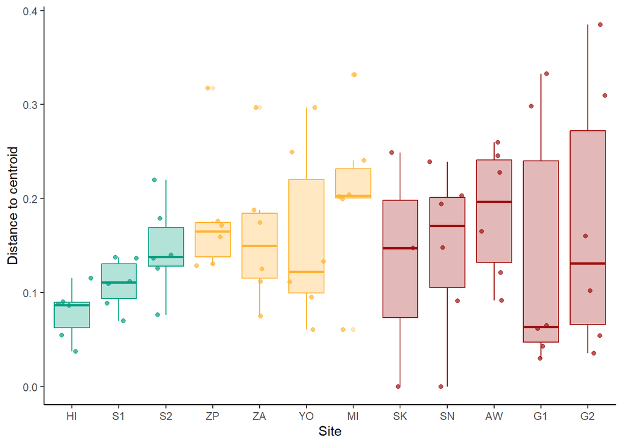

```r
box<- ggplot(data=distcent_df,aes(x=Site,y=Distance_to_centroid))+
  geom_boxplot(aes(fill=Pressure,colour=Pressure),alpha=0.3)+
  geom_jitter(aes(color=Pressure),alpha=0.7)+
  theme_classic()+
  ylab(label="Distance to centroid")+
  theme(legend.position = "none")+ #remove legend
  scale_fill_manual(values=c("#009F81", "#FFB331","#9F1111"))+
  scale_color_manual(values=c("#009F81", "#FFB331","#9F1111"))
box
```

[figure not shown]

```r
ggpubr:: ggarrange(box,
                   gridExtra::tableGrob(distcent_df_mean),
                   ncol = 2, widths = c(1,1))
```

```r
ggsave("func_boxplot.tiff",
       units="in", width=12, height=4, dpi=300, compression = 'lzw',
       path = here("Multi-taxa_data","PLITs","4-Visualization_outputs"))

ggsave("func_boxplot.png",
       units="in", width=12, height=4, dpi=300,
       path = here("Multi-taxa_data","PLITs","4-Visualization_outputs"))
```

# 6 SIMPER: Similarity of percentage

From the vignette: *The simper functions performs pairwise comparisons of groups of sampling units and finds the contribution of each species to the average between-group Bray-Curtis dissimilarity. Although the method is called simper, it really studied dissimilarities instead of similarities (Clarke 1993).*

## 6.1 SIMPER PER SITE:

```r
func_sim_site=simper(func_mat,group=ind_df$Site) #Distinguish categories which caused the differences in relative cover among sites
func_sim_site
```

```
## cumulative contributions of most influential species:
##
## $AW_G1
## encrusting submassive      table       turf
##  0.3749590  0.5577542  0.6470783  0.7106057
##
## $AW_G2
## encrusting submassive      table       turf        CCA
##  0.3056263  0.5090309  0.6149500  0.6980995  0.7812490
##
## $AW_HI
## encrusting submassive  branching      table       turf        CCA
##  0.1885738  0.3674302  0.4764707  0.5798990  0.6591003  0.7383016
##
## $AW_MI
## encrusting    laminar submassive      table
##  0.2327542  0.4425973  0.6293605  0.7271581
##
## $AW_S1
## encrusting submassive  branching       turf        CCA    massive
##  0.1864682  0.3484461  0.4614190  0.5577597  0.6528901  0.7440329
##
## $AW_S2
## submassive encrusting  branching      table       turf        CCA
##  0.2053904  0.4026388  0.5048469  0.5995147  0.6836079  0.7677011
##
## $AW_SK
##      table submassive encrusting    massive  branching
##  0.2371254  0.4236218  0.6045187  0.6943048  0.7698469
##
## $AW_SN
## encrusting submassive      table    massive
##  0.2605297  0.4703175  0.6111813  0.7151423
##
## $AW_YO
## encrusting submassive       turf        CCA      table
##  0.2243639  0.3776797  0.5029102  0.6281406  0.7386366
##
## $AW_ZA
## submassive encrusting  corymbose    massive       turf        CCA
```

[output cut: 210 more lines]

```
## $SN_ZP
## encrusting      table       turf        CCA  branching
##  0.1702632  0.3342031  0.4831869  0.6319911  0.7471582
##
## $YO_ZA
## encrusting  corymbose      table    massive        CCA       turf
##  0.2017136  0.3346007  0.4583258  0.5602709  0.6614795  0.7498412
##
## $YO_ZP
## encrusting      table  branching        CCA       turf
##  0.2011801  0.3746694  0.5129416  0.6464250  0.7798017
##
## $ZA_ZP
## encrusting      table  corymbose  branching        CCA    massive
##  0.1541485  0.2985899  0.4347469  0.5529469  0.6507686  0.7372643
```

```r
summary(func_sim_site) #check which categories were the main driver of difference among sites
```

```
##
## Contrast: AW_G1
##
##             average       sd    ratio      ava      avb cumsum     p
## encrusting  0.14470  0.07945  1.82110 22.60000 74.73000  0.375 0.001 ***
## submassive  0.07054  0.04254  1.65840 29.37000  1.88000  0.558 0.007 **
## table       0.03447  0.04683  0.73610  8.15000  7.92000  0.647 0.623
## turf        0.02452  0.03028  0.80970 99.38000 90.18000  0.711 0.570
## CCA         0.02394  0.03042  0.78710  0.62000  9.60000  0.773 0.613
## massive     0.02155  0.02575  0.83680  8.45000  1.73000  0.829 0.396
## foliose     0.02076  0.03105  0.66860  0.00000  7.87000  0.882 0.004 **
## plate       0.01165  0.00968  1.20280  4.10000  3.25000  0.912 0.259
## laminar     0.01137  0.02580  0.44100  4.55000  0.00000  0.942 0.529
## hispidose   0.01046  0.02132  0.49050  4.18000  0.00000  0.969 0.455
## branching   0.00638  0.01458  0.43730  0.00000  2.42000  0.986 1.000
## corymbose   0.00500  0.00647  0.77310  1.92000  0.22000  0.999 0.978
## macroalgae  0.00057  0.00131  0.43730  0.00000  0.22000  1.000 0.425
## digitate    0.00000  0.00000      NaN  0.00000  0.00000  1.000    NA
## ---
## Signif. codes:  0 '***' 0.001 '**' 0.01 '*' 0.05 '.' 0.1 ' ' 1
##
## Contrast: AW_G2
##
##             average       sd    ratio      ava      avb cumsum     p
## encrusting  0.11645  0.07132  1.63280 22.60000 56.62000  0.306 0.002 **
## submassive  0.07750  0.04880  1.58830 29.37000  0.00000  0.509 0.001 ***
## table       0.04036  0.05596  0.72110  8.15000  9.72000  0.615 0.474
## turf        0.03168  0.02669  1.18680 99.38000 87.52000  0.698 0.197
## CCA         0.03168  0.02669  1.18680  0.62000 12.48000  0.781 0.210
## massive     0.02588  0.02517  1.02810  8.45000  5.18000  0.849 0.164
## plate       0.02576  0.02509  1.02680  4.10000 10.45000  0.917 0.002 **
## laminar     0.01201  0.02745  0.43730  4.55000  0.00000  0.948 0.488
## hispidose   0.01104  0.02270  0.48640  4.18000  0.00000  0.977 0.387
## corymbose   0.00506  0.00733  0.68970  1.92000  0.00000  0.991 0.983
## foliose     0.00361  0.00825  0.43730  0.00000  1.37000  1.000 0.508
## branching   0.00000  0.00000      NaN  0.00000  0.00000  1.000    NA
## digitate    0.00000  0.00000      NaN  0.00000  0.00000  1.000    NA
## macroalgae  0.00000  0.00000      NaN  0.00000  0.00000  1.000    NA
## ---
## Signif. codes:  0 '***' 0.001 '**' 0.01 '*' 0.05 '.' 0.1 ' ' 1
```

[output cut: 1267 more lines]

```
## branching   0.03842  0.02443  1.57300  4.33000 18.25000  0.553 0.008 **
## CCA         0.03180  0.02426  1.31080 11.32000 20.55000  0.651 0.209
## massive     0.02811  0.01614  1.74230 16.52000  6.05000  0.737 0.079 .
## turf        0.02638  0.02249  1.17290 86.47000 79.42000  0.818 0.458
## submassive  0.02074  0.01459  1.42170 10.52000  6.55000  0.882 0.958
## hispidose   0.01410  0.00990  1.42400  7.55000  3.07000  0.926 0.185
## plate       0.00783  0.01019  0.76870  3.13000  0.00000  0.950 0.637
## digitate    0.00735  0.00676  1.08750  3.10000  0.42000  0.972 0.112
## macroalgae  0.00554  0.00783  0.70760  2.22000  0.03000  0.989 0.005 **
## laminar     0.00346  0.00667  0.51820  1.38000  0.00000  1.000 0.608
## foliose     0.00000  0.00000      NaN  0.00000  0.00000  1.000    NA
## ---
## Signif. codes:  0 '***' 0.001 '**' 0.01 '*' 0.05 '.' 0.1 ' ' 1
## Permutation: free
## Number of permutations: 999
```

## 6.2 SIMPER per depth

```r
func_sim_depth=simper(func_mat,group=ind_df$Depth) #Distinguish categories which caused the differences in relative cover among sites
func_sim_depth
```

```
## cumulative contributions of most influential species:
##
## $Deep_Shallow
## encrusting      table submassive        CCA       turf  branching
##  0.2212028  0.3584190  0.4906206  0.5717904  0.6523529  0.7259607
```

```r
summary(func_sim_depth, ordered=T, digits=3) #check which categories were the main driver of difference among sites
```

```
##
## Contrast: Deep_Shallow
##
##            average      sd   ratio     ava     avb cumsum     p
## encrusting  0.0695  0.0544  1.2780 48.6000 36.8000   0.22 0.027 *
## table       0.0431  0.0412  1.0470  6.6000 16.7000   0.36 0.007 **
## submassive  0.0415  0.0397  1.0460 12.7000 13.8000   0.49 0.268
## CCA         0.0255  0.0233  1.0930  9.1000 11.2000   0.57 0.931
## turf        0.0253  0.0229  1.1030 90.4000 88.8000   0.65 0.919
## branching   0.0231  0.0201  1.1490  7.3000  7.6000   0.73 0.603
## massive     0.0196  0.0187  1.0470  6.8000  7.1000   0.79 0.620
## corymbose   0.0195  0.0238  0.8190  2.4000  7.4000   0.85 0.013 *
## laminar     0.0157  0.0448  0.3500  4.4000  2.1000   0.90 0.296
## plate       0.0107  0.0144  0.7460  3.5000  1.4000   0.94 0.005 **
## hispidose   0.0100  0.0133  0.7550  3.0000  2.0000   0.97 0.176
## foliose     0.0048  0.0143  0.3390  0.9000  1.1000   0.98 0.540
## digitate    0.0044  0.0066  0.6720  0.9000  1.2000   1.00 0.960
## macroalgae  0.0013  0.0040  0.3160  0.5000  0.0000   1.00 0.004 **
## ---
## Signif. codes:  0 '***' 0.001 '**' 0.01 '*' 0.05 '.' 0.1 ' ' 1
## Permutation: free
## Number of permutations: 999
```

## 6.3 SIMPER per pressure exposure

```r
func_sim_pres=simper(func_mat,group=ind_df$Pressure) #Distinguish categories which caused the differences in relative cover among sites
func_sim_pres
```

```
## cumulative contributions of most influential species:
##
## $High_Low
## encrusting submassive      table  branching       turf
##  0.2206283  0.4149529  0.5381466  0.6302910  0.7053790
##
## $High_Medium
## encrusting      table       turf        CCA submassive  corymbose
##  0.2304820  0.3669316  0.4629481  0.5575635  0.6406081  0.7102545
##
## $Low_Medium
## submassive encrusting      table  branching        CCA       turf
##  0.1870422  0.3511130  0.4606305  0.5518254  0.6331139  0.7117943
```

```r
summary(func_sim_pres, ordered=T, digits=3) #check which categories were the main driver of difference among sites
```

```
##
## Contrast: High_Low
##
##            average      sd   ratio     ava     avb cumsum     p
## encrusting  0.0692  0.0470  1.4730 48.2000 36.3000   0.22 0.352
## submassive  0.0609  0.0458  1.3300  9.3000 27.1000   0.42 0.001 ***
## table       0.0386  0.0368  1.0510 13.0000  8.1000   0.54 0.663
## branching   0.0289  0.0193  1.4990  2.9000 12.8000   0.63 0.002 **
## turf        0.0235  0.0168  1.4040 93.9000 89.2000   0.70 0.784
## CCA         0.0235  0.0167  1.4080  6.1000 10.7000   0.78 0.810
## massive     0.0187  0.0189  0.9930  6.9000  5.7000   0.84 0.694
## hispidose   0.0114  0.0146  0.7840  0.9000  3.9000   0.88 0.172
## plate       0.0113  0.0162  0.6990  4.5000  0.5000   0.91 0.248
## corymbose   0.0109  0.0132  0.8250  3.5000  2.2000   0.95 0.998
## foliose     0.0065  0.0161  0.4020  2.2000  0.6000   0.97 0.235
## digitate    0.0064  0.0080  0.7970  0.1000  2.5000   0.99 0.006 **
## laminar     0.0033  0.0128  0.2610  1.0000  0.3000   1.00 0.986
## macroalgae  0.0002  0.0006  0.3360  0.0000  0.0000   1.00 0.969
## ---
## Signif. codes:  0 '***' 0.001 '**' 0.01 '*' 0.05 '.' 0.1 ' ' 1
##
## Contrast: High_Medium
##
##            average      sd   ratio     ava     avb cumsum     p
## encrusting  0.0777  0.0561  1.3840 48.2000 40.7000   0.23 0.003 **
## table       0.0460  0.0437  1.0530 13.0000 13.4000   0.37 0.019 *
## turf        0.0324  0.0269  1.2030 93.9000 85.0000   0.46 0.001 ***
## CCA         0.0319  0.0275  1.1600  6.1000 14.4000   0.56 0.002 **
## submassive  0.0280  0.0286  0.9790  9.3000  7.4000   0.64 1.000
## corymbose   0.0235  0.0269  0.8740  3.5000  8.7000   0.71 0.001 ***
## branching   0.0221  0.0220  1.0050  2.9000  8.4000   0.78 0.793
## massive     0.0220  0.0194  1.1340  6.9000  7.8000   0.84 0.047 *
## laminar     0.0219  0.0529  0.4140  1.0000  7.9000   0.91 0.011 *
## plate       0.0121  0.0160  0.7590  4.5000  1.5000   0.94 0.013 *
## hispidose   0.0095  0.0126  0.7510  0.9000  3.1000   0.97 0.668
## foliose     0.0055  0.0160  0.3410  2.2000  0.0000   0.99 0.479
## digitate    0.0028  0.0051  0.5630  0.1000  1.0000   1.00 0.993
## macroalgae  0.0016  0.0047  0.3520  0.0000  0.6000   1.00 0.034 *
## ---
## Signif. codes:  0 '***' 0.001 '**' 0.01 '*' 0.05 '.' 0.1 ' ' 1
##
## Contrast: Low_Medium
##
##            average      sd   ratio     ava     avb cumsum     p
## submassive  0.0538  0.0435  1.2360 27.1000  7.4000   0.19 0.004 **
## encrusting  0.0472  0.0368  1.2820 36.3000 40.7000   0.35 1.000
## table       0.0315  0.0336  0.9370  8.1000 13.4000   0.46 0.955
## branching   0.0262  0.0180  1.4590 12.8000  8.4000   0.55 0.049 *
## CCA         0.0234  0.0216  1.0820 10.7000 14.4000   0.63 0.819
## turf        0.0226  0.0216  1.0460 89.2000 85.0000   0.71 0.862
## corymbose   0.0208  0.0261  0.7980  2.2000  8.7000   0.78 0.249
## laminar     0.0201  0.0511  0.3930  0.3000  7.9000   0.85 0.266
## massive     0.0164  0.0144  1.1400  5.7000  7.8000   0.91 0.940
## hispidose   0.0115  0.0110  1.0470  3.9000  3.1000   0.95 0.195
## digitate    0.0067  0.0074  0.9120  2.5000  1.0000   0.97 0.003 **
## plate       0.0043  0.0069  0.6210  0.5000  1.5000   0.99 0.999
## macroalgae  0.0016  0.0045  0.3490  0.0000  0.6000   1.00 0.317
## foliose     0.0015  0.0051  0.2920  0.6000  0.0000   1.00 0.959
## ---
## Signif. codes:  0 '***' 0.001 '**' 0.01 '*' 0.05 '.' 0.1 ' ' 1
## Permutation: free
## Number of permutations: 999
```

# 8 References

```r
#install.packages("report")
library(report)
report(sessionInfo())
```

```
## Analyses were conducted using the R Statistical language (version 4.5.0; R Core
## Team, 2025) on Windows 11 x64 (build 22631), using the packages spData (version
## 2.3.4; Bivand R et al., 2025), spdep (version 1.3.11; Bivand R, Wong D, 2018),
## ggnewscale (version 0.5.1; Campitelli E, 2025), fields (version 16.3.1; Douglas
## Nychka et al., 2021), adespatial (version 0.3.28; Dray S et al., 2025), ade4
## (version 1.7.23; Dray S, Dufour A, 2007), spam (version 2.11.1; Furrer R et
## al., 2024), viridisLite (version 0.4.2; Garnier et al., 2023), lubridate
## (version 1.9.4; Grolemund G, Wickham H, 2011), report (version 0.6.1; Makowski
## D et al., 2023), colorblindr (version 0.1.0; McWhite C, Wilke C, 2022), here
## (version 1.0.1; Müller K, 2020), tibble (version 3.2.1; Müller K, Wickham H,
## 2023), vegan (version 2.6.10; Oksanen J et al., 2025), sf (version 1.0.21;
## Pebesma E, Bivand R, 2023), ggforce (version 0.4.2; Pedersen T, 2024), lattice
## (version 0.22.6; Sarkar D, 2008), permute (version 0.9.7; Simpson G, 2022),
## MASS (version 7.3.65; Venables WN, Ripley BD, 2002), reshape2 (version 1.4.4;
## Wickham H, 2007), ggplot2 (version 3.5.2; Wickham H, 2016), forcats (version
## 1.0.0; Wickham H, 2023), stringr (version 1.5.1; Wickham H, 2023), tidyverse
## (version 2.0.0; Wickham H et al., 2019), readxl (version 1.4.5; Wickham H,
## Bryan J, 2025), dplyr (version 1.1.4; Wickham H et al., 2023), purrr (version
## 1.0.4; Wickham H, Henry L, 2025), readr (version 2.1.5; Wickham H et al.,
## 2024), tidyr (version 1.3.1; Wickham H et al., 2024) and colorspace (version
## 2.1.0; Zeileis A et al., 2020).
##
## References
## ----------
##   - Bivand R, Nowosad J, Lovelace R (2025). _spData: Datasets for Spatial
## Analysis_. doi:10.32614/CRAN.package.spData
## <https://doi.org/10.32614/CRAN.package.spData>, R package version 2.3.4,
## <https://CRAN.R-project.org/package=spData>.
##   - Bivand R, Wong D (2018). "Comparing implementations of global and local
## indicators of spatial association." _TEST_, *27*(3), 716-748.
## doi:10.1007/s11749-018-0599-x <https://doi.org/10.1007/s11749-018-0599-x>.
## Roger Bivand (2022). "R Packages for Analyzing Spatial Data: A Comparative Case
## Study with Areal Data." _Geographical Analysis_, *54*(3), 488-518.
## doi:10.1111/gean.12319 <https://doi.org/10.1111/gean.12319>. Bivand R, Pebesma
## E, Gómez-Rubio V (2013). _Applied spatial data analysis with R, Second
## edition_. Springer, NY. <https://asdar-book.org/>. Pebesma E, Bivand R (2023).
## _Spatial Data Science With Applications in R_. Chapman & Hall.
## <https://r-spatial.org/book/>.
##   - Campitelli E (2025). _ggnewscale: Multiple Fill and Colour Scales in
## 'ggplot2'_. doi:10.32614/CRAN.package.ggnewscale
```

[output cut: 123 more lines]

```
## R package version 2.1.5, <https://CRAN.R-project.org/package=readr>.
##   - Wickham H, Vaughan D, Girlich M (2024). _tidyr: Tidy Messy Data_.
## doi:10.32614/CRAN.package.tidyr <https://doi.org/10.32614/CRAN.package.tidyr>,
## R package version 1.3.1, <https://CRAN.R-project.org/package=tidyr>.
##   - Zeileis A, Fisher JC, Hornik K, Ihaka R, McWhite CD, Murrell P, Stauffer R,
## Wilke CO (2020). "colorspace: A Toolbox for Manipulating and Assessing Colors
## and Palettes." _Journal of Statistical Software_, *96*(1), 1-49.
## doi:10.18637/jss.v096.i01 <https://doi.org/10.18637/jss.v096.i01>. Zeileis A,
## Hornik K, Murrell P (2009). "Escaping RGBland: Selecting Colors for Statistical
## Graphics." _Computational Statistics & Data Analysis_, *53*(9), 3259-3270.
## doi:10.1016/j.csda.2008.11.033 <https://doi.org/10.1016/j.csda.2008.11.033>.
## Stauffer R, Mayr GJ, Dabernig M, Zeileis A (2009). "Somewhere over the Rainbow:
## How to Make Effective Use of Colors in Meteorological Visualizations."
## _Bulletin of the American Meteorological Society_, *96*(2), 203-216.
## doi:10.1175/BAMS-D-13-00155.1 <https://doi.org/10.1175/BAMS-D-13-00155.1>.
```